# Risk Factor Analysis

## Outcome Variable

**Outcome Variable:** sstunted

## Predictor Variables

**Intervention Variable:** parity

**Adjustment Set:**

- arm
- W_mage
- meducyrs
- feducyrs
- hhwealth_quart
- hfoodsec
- W_mhtcm
- vagbrth
- W_nrooms
- impfloor
- impsan
- safeh20
- delta_W_mage
- delta_meducyrs
- delta_feducyrs
- delta_hhwealth_quart
- delta_hfoodsec
- delta_W_mhtcm
- delta_vagbrth
- delta_W_nrooms
- delta_impfloor
- delta_impsan
- delta_safeh20

## Stratifying Variables

The analysis was stratified on these variable(s):

- agecat
- studyid
- country

## Data Summary

| agecat | studyid | country | parity | sstunted | n_cell | n |
| --- | --- | --- | --- | --- | --- | --- |
| Birth | ki1000304b-SAS-CompFeed | INDIA | 1 | 0 | 44 | 187 |
| Birth | ki1000304b-SAS-CompFeed | INDIA | 1 | 1 | 3 | 187 |
| Birth | ki1000304b-SAS-CompFeed | INDIA | 2 | 0 | 47 | 187 |
| Birth | ki1000304b-SAS-CompFeed | INDIA | 2 | 1 | 6 | 187 |
| Birth | ki1000304b-SAS-CompFeed | INDIA | 3+ | 0 | 85 | 187 |
| Birth | ki1000304b-SAS-CompFeed | INDIA | 3+ | 1 | 2 | 187 |
| Birth | ki1101329-Keneba | GAMBIA | 1 | 0 | 153 | 1407 |
| Birth | ki1101329-Keneba | GAMBIA | 1 | 1 | 3 | 1407 |
| Birth | ki1101329-Keneba | GAMBIA | 2 | 0 | 144 | 1407 |
| Birth | ki1101329-Keneba | GAMBIA | 2 | 1 | 2 | 1407 |
| Birth | ki1101329-Keneba | GAMBIA | 3+ | 0 | 1084 | 1407 |
| Birth | ki1101329-Keneba | GAMBIA | 3+ | 1 | 21 | 1407 |
| Birth | ki1126311-ZVITAMBO | ZIMBABWE | 1 | 0 | 5777 | 13829 |
| Birth | ki1126311-ZVITAMBO | ZIMBABWE | 1 | 1 | 195 | 13829 |
| Birth | ki1126311-ZVITAMBO | ZIMBABWE | 2 | 0 | 4022 | 13829 |
| Birth | ki1126311-ZVITAMBO | ZIMBABWE | 2 | 1 | 103 | 13829 |
| Birth | ki1126311-ZVITAMBO | ZIMBABWE | 3+ | 0 | 3589 | 13829 |
| Birth | ki1126311-ZVITAMBO | ZIMBABWE | 3+ | 1 | 143 | 13829 |
| Birth | ki1135781-COHORTS | GUATEMALA | 1 | 0 | 109 | 852 |
| Birth | ki1135781-COHORTS | GUATEMALA | 1 | 1 | 3 | 852 |
| Birth | ki1135781-COHORTS | GUATEMALA | 2 | 0 | 134 | 852 |
| Birth | ki1135781-COHORTS | GUATEMALA | 2 | 1 | 3 | 852 |
| Birth | ki1135781-COHORTS | GUATEMALA | 3+ | 0 | 598 | 852 |
| Birth | ki1135781-COHORTS | GUATEMALA | 3+ | 1 | 5 | 852 |
| Birth | ki1135781-COHORTS | INDIA | 1 | 0 | 674 | 4122 |
| Birth | ki1135781-COHORTS | INDIA | 1 | 1 | 22 | 4122 |
| Birth | ki1135781-COHORTS | INDIA | 2 | 0 | 1016 | 4122 |
| Birth | ki1135781-COHORTS | INDIA | 2 | 1 | 21 | 4122 |
| Birth | ki1135781-COHORTS | INDIA | 3+ | 0 | 2319 | 4122 |
| Birth | ki1135781-COHORTS | INDIA | 3+ | 1 | 70 | 4122 |

[output cut: 132 more lines]

The following strata were considered:

- agecat: 24 months, studyid: ki1017093b-PROVIDE, country: BANGLADESH
- agecat: 24 months, studyid: ki1066203-TanzaniaChild2, country: TANZANIA, UNITED REPUBLIC OF
- agecat: 24 months, studyid: ki1101329-Keneba, country: GAMBIA
- agecat: 24 months, studyid: ki1113344-GMS-Nepal, country: NEPAL
- agecat: 24 months, studyid: ki1126311-ZVITAMBO, country: ZIMBABWE
- agecat: 24 months, studyid: ki1135781-COHORTS, country: GUATEMALA
- agecat: 24 months, studyid: ki1135781-COHORTS, country: INDIA
- agecat: 24 months, studyid: ki1135781-COHORTS, country: PHILIPPINES
- agecat: 24 months, studyid: kiGH5241-JiVitA-3, country: BANGLADESH
- agecat: 6 months, studyid: ki1000304b-SAS-CompFeed, country: INDIA
- agecat: 6 months, studyid: ki1000304b-SAS-FoodSuppl, country: INDIA
- agecat: 6 months, studyid: ki1017093b-PROVIDE, country: BANGLADESH
- agecat: 6 months, studyid: ki1066203-TanzaniaChild2, country: TANZANIA, UNITED REPUBLIC OF
- agecat: 6 months, studyid: ki1101329-Keneba, country: GAMBIA
- agecat: 6 months, studyid: ki1113344-GMS-Nepal, country: NEPAL
- agecat: 6 months, studyid: ki1126311-ZVITAMBO, country: ZIMBABWE
- agecat: 6 months, studyid: ki1135781-COHORTS, country: GUATEMALA
- agecat: 6 months, studyid: ki1135781-COHORTS, country: INDIA
- agecat: 6 months, studyid: ki1135781-COHORTS, country: PHILIPPINES
- agecat: 6 months, studyid: kiGH5241-JiVitA-3, country: BANGLADESH
- agecat: Birth, studyid: ki1000304b-SAS-CompFeed, country: INDIA
- agecat: Birth, studyid: ki1101329-Keneba, country: GAMBIA
- agecat: Birth, studyid: ki1126311-ZVITAMBO, country: ZIMBABWE
- agecat: Birth, studyid: ki1135781-COHORTS, country: GUATEMALA
- agecat: Birth, studyid: ki1135781-COHORTS, country: INDIA
- agecat: Birth, studyid: ki1135781-COHORTS, country: PHILIPPINES
- agecat: Birth, studyid: kiGH5241-JiVitA-3, country: BANGLADESH

### Dropped Strata

Some strata were dropped due to rare outcomes:

- agecat: Birth, studyid: ki1000304b-SAS-CompFeed, country: INDIA
- agecat: Birth, studyid: ki1101329-Keneba, country: GAMBIA
- agecat: Birth, studyid: ki1135781-COHORTS, country: GUATEMALA
- agecat: 6 months, studyid: ki1017093b-PROVIDE, country: BANGLADESH
- agecat: 6 months, studyid: ki1066203-TanzaniaChild2, country: TANZANIA, UNITED REPUBLIC OF
- agecat: 6 months, studyid: ki1101329-Keneba, country: GAMBIA
- agecat: 24 months, studyid: ki1066203-TanzaniaChild2, country: TANZANIA, UNITED REPUBLIC OF
- agecat: 24 months, studyid: ki1101329-Keneba, country: GAMBIA

## Methods Detail

We’re interested in the causal parameters $E[Y_a]$ for all values of $a \in \mathcal{A}$. These parameters represent the mean outcome if, possibly contrary to fact, we intervened to set all units to have $A=a$. Under the randomization and positivity assumptions, these are identified by the statistical parameters $\psi_a=E_W[E_{Y|A,W}(Y|A=a,W)]$. In addition, we’re interested in the mean of $Y$, $E[Y]$ under no intervention (the observed mean). We will estimate these parameters by using SuperLearner to fit the relevant likelihood factors – $E_{Y|A,W}(Y|A=a,W)$ and $p(A=a|W)$, and then updating our likelihood fit using a joint TMLE.

For unadjusted analyses ($W=\{\}$), initial likelihoods were estimated using Lrnr_glm to estimate the simple $E(Y|A)$ and Lrnr_mean to estimate $p(A)$. For adjusted analyses, a small library containing Lrnr_glmnet, Lrnr_xgboost, and Lrnr_mean was used.

Having estimated these parameters, we will then use the delta method to estimate relative risks and attributable risks relative to a prespecified baseline level of $A$.

# Results Detail

## Results Plots

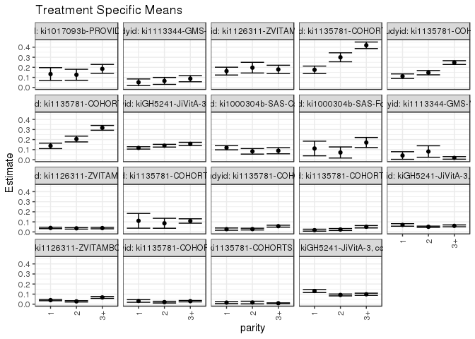

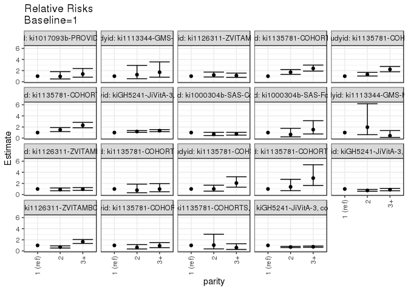

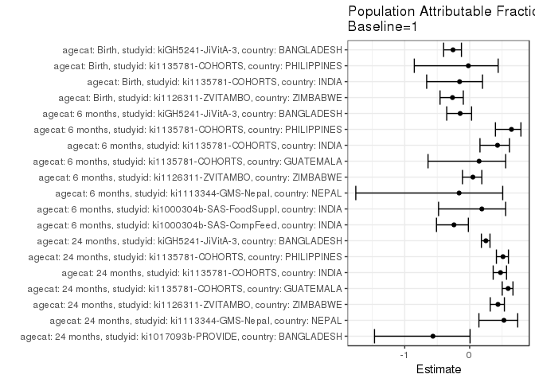

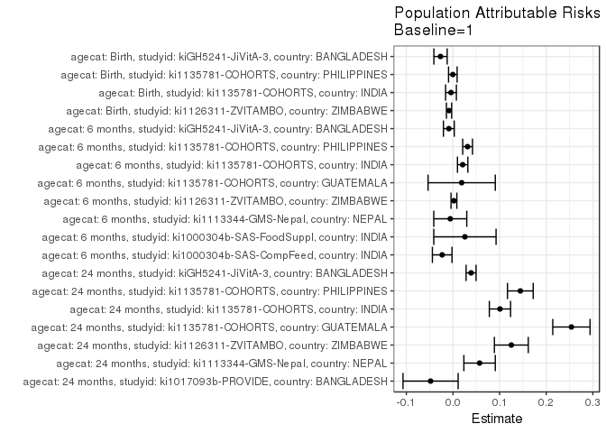

## Results Table

### Parameter: TSM

| agecat | studyid | country | intervention_level | baseline_level | estimate | ci_lower | ci_upper |
| --- | --- | --- | --- | --- | --- | --- | --- |
| Birth | ki1126311-ZVITAMBO | ZIMBABWE | 1 | NA | 0.0403322 | 0.0341311 | 0.0465334 |
| Birth | ki1126311-ZVITAMBO | ZIMBABWE | 2 | NA | 0.0278220 | 0.0213377 | 0.0343064 |
| Birth | ki1126311-ZVITAMBO | ZIMBABWE | 3+ | NA | 0.0671197 | 0.0574424 | 0.0767969 |
| Birth | ki1135781-COHORTS | INDIA | 1 | NA | 0.0316632 | 0.0188217 | 0.0445047 |
| Birth | ki1135781-COHORTS | INDIA | 2 | NA | 0.0202027 | 0.0117561 | 0.0286494 |
| Birth | ki1135781-COHORTS | INDIA | 3+ | NA | 0.0296144 | 0.0228535 | 0.0363752 |
| Birth | ki1135781-COHORTS | PHILIPPINES | 1 | NA | 0.0153882 | 0.0052675 | 0.0255089 |
| Birth | ki1135781-COHORTS | PHILIPPINES | 2 | NA | 0.0161072 | 0.0028427 | 0.0293716 |
| Birth | ki1135781-COHORTS | PHILIPPINES | 3+ | NA | 0.0090965 | 0.0051760 | 0.0130170 |
| Birth | kiGH5241-JiVitA-3 | BANGLADESH | 1 | NA | 0.1308254 | 0.1157068 | 0.1459439 |
| Birth | kiGH5241-JiVitA-3 | BANGLADESH | 2 | NA | 0.0915125 | 0.0824236 | 0.1006013 |
| Birth | kiGH5241-JiVitA-3 | BANGLADESH | 3+ | NA | 0.0982884 | 0.0874929 | 0.1090839 |
| 6 months | ki1000304b-SAS-CompFeed | INDIA | 1 | NA | 0.1189534 | 0.0983239 | 0.1395829 |
| 6 months | ki1000304b-SAS-CompFeed | INDIA | 2 | NA | 0.0829820 | 0.0554611 | 0.1105030 |
| 6 months | ki1000304b-SAS-CompFeed | INDIA | 3+ | NA | 0.0889956 | 0.0583707 | 0.1196206 |
| 6 months | ki1000304b-SAS-FoodSuppl | INDIA | 1 | NA | 0.1111111 | 0.0384223 | 0.1837999 |
| 6 months | ki1000304b-SAS-FoodSuppl | INDIA | 2 | NA | 0.0714286 | 0.0162799 | 0.1265772 |
| 6 months | ki1000304b-SAS-FoodSuppl | INDIA | 3+ | NA | 0.1705069 | 0.1204022 | 0.2206116 |
| 6 months | ki1113344-GMS-Nepal | NEPAL | 1 | NA | 0.0413169 | 0.0035832 | 0.0790505 |
| 6 months | ki1113344-GMS-Nepal | NEPAL | 2 | NA | 0.0812070 | 0.0241783 | 0.1382356 |
| 6 months | ki1113344-GMS-Nepal | NEPAL | 3+ | NA | 0.0176811 | 0.0049829 | 0.0303794 |
| 6 months | ki1126311-ZVITAMBO | ZIMBABWE | 1 | NA | 0.0396590 | 0.0325059 | 0.0468120 |
| 6 months | ki1126311-ZVITAMBO | ZIMBABWE | 2 | NA | 0.0356162 | 0.0282030 | 0.0430295 |
| 6 months | ki1126311-ZVITAMBO | ZIMBABWE | 3+ | NA | 0.0381948 | 0.0309329 | 0.0454566 |
| 6 months | ki1135781-COHORTS | GUATEMALA | 1 | NA | 0.1103807 | 0.0370314 | 0.1837300 |
| 6 months | ki1135781-COHORTS | GUATEMALA | 2 | NA | 0.0859194 | 0.0364092 | 0.1354296 |
| 6 months | ki1135781-COHORTS | GUATEMALA | 3+ | NA | 0.1086065 | 0.0867276 | 0.1304854 |
| 6 months | ki1135781-COHORTS | INDIA | 1 | NA | 0.0276995 | 0.0164386 | 0.0389604 |
| 6 months | ki1135781-COHORTS | INDIA | 2 | NA | 0.0280708 | 0.0195213 | 0.0366202 |
| 6 months | ki1135781-COHORTS | INDIA | 3+ | NA | 0.0571398 | 0.0477115 | 0.0665680 |
| 6 months | ki1135781-COHORTS | PHILIPPINES | 1 | NA | 0.0173936 | 0.0077999 | 0.0269873 |
| 6 months | ki1135781-COHORTS | PHILIPPINES | 2 | NA | 0.0240196 | 0.0140952 | 0.0339440 |
| 6 months | ki1135781-COHORTS | PHILIPPINES | 3+ | NA | 0.0514057 | 0.0397537 | 0.0630576 |
| 6 months | kiGH5241-JiVitA-3 | BANGLADESH | 1 | NA | 0.0695052 | 0.0569068 | 0.0821036 |
| 6 months | kiGH5241-JiVitA-3 | BANGLADESH | 2 | NA | 0.0510695 | 0.0446344 | 0.0575046 |
| 6 months | kiGH5241-JiVitA-3 | BANGLADESH | 3+ | NA | 0.0603805 | 0.0512146 | 0.0695465 |
| 24 months | ki1017093b-PROVIDE | BANGLADESH | 1 | NA | 0.1329500 | 0.0693616 | 0.1965385 |
| 24 months | ki1017093b-PROVIDE | BANGLADESH | 2 | NA | 0.1258231 | 0.0711635 | 0.1804827 |
| 24 months | ki1017093b-PROVIDE | BANGLADESH | 3+ | NA | 0.1845245 | 0.1401639 | 0.2288851 |
| 24 months | ki1113344-GMS-Nepal | NEPAL | 1 | NA | 0.0511473 | 0.0180221 | 0.0842725 |
| 24 months | ki1113344-GMS-Nepal | NEPAL | 2 | NA | 0.0646475 | 0.0301126 | 0.0991823 |
| 24 months | ki1113344-GMS-Nepal | NEPAL | 3+ | NA | 0.0870526 | 0.0565235 | 0.1175816 |
| 24 months | ki1126311-ZVITAMBO | ZIMBABWE | 1 | NA | 0.1621340 | 0.1233480 | 0.2009200 |
| 24 months | ki1126311-ZVITAMBO | ZIMBABWE | 2 | NA | 0.1965230 | 0.1433715 | 0.2496746 |
| 24 months | ki1126311-ZVITAMBO | ZIMBABWE | 3+ | NA | 0.1789720 | 0.1374740 | 0.2204700 |
| 24 months | ki1135781-COHORTS | GUATEMALA | 1 | NA | 0.1752254 | 0.1381400 | 0.2123108 |
| 24 months | ki1135781-COHORTS | GUATEMALA | 2 | NA | 0.2995735 | 0.2549440 | 0.3442029 |
| 24 months | ki1135781-COHORTS | GUATEMALA | 3+ | NA | 0.4188098 | 0.3862386 | 0.4513811 |
| 24 months | ki1135781-COHORTS | INDIA | 1 | NA | 0.1114841 | 0.0887058 | 0.1342625 |
| 24 months | ki1135781-COHORTS | INDIA | 2 | NA | 0.1466090 | 0.1252459 | 0.1679722 |
| 24 months | ki1135781-COHORTS | INDIA | 3+ | NA | 0.2469955 | 0.2281407 | 0.2658502 |
| 24 months | ki1135781-COHORTS | PHILIPPINES | 1 | NA | 0.1372951 | 0.1100804 | 0.1645097 |
| 24 months | ki1135781-COHORTS | PHILIPPINES | 2 | NA | 0.2053423 | 0.1765761 | 0.2341085 |
| 24 months | ki1135781-COHORTS | PHILIPPINES | 3+ | NA | 0.3165406 | 0.2927016 | 0.3403796 |
| 24 months | kiGH5241-JiVitA-3 | BANGLADESH | 1 | NA | 0.1169024 | 0.1051133 | 0.1286914 |
| 24 months | kiGH5241-JiVitA-3 | BANGLADESH | 2 | NA | 0.1387891 | 0.1253351 | 0.1522430 |
| 24 months | kiGH5241-JiVitA-3 | BANGLADESH | 3+ | NA | 0.1566966 | 0.1410589 | 0.1723344 |

### Parameter: E(Y)

| agecat | studyid | country | intervention_level | baseline_level | estimate | ci_lower | ci_upper |
| --- | --- | --- | --- | --- | --- | --- | --- |
| Birth | ki1126311-ZVITAMBO | ZIMBABWE | NA | NA | 0.0318895 | 0.0289609 | 0.0348181 |
| Birth | ki1135781-COHORTS | INDIA | NA | NA | 0.0274139 | 0.0224285 | 0.0323992 |
| Birth | ki1135781-COHORTS | PHILIPPINES | NA | NA | 0.0150820 | 0.0107558 | 0.0194081 |
| Birth | kiGH5241-JiVitA-3 | BANGLADESH | NA | NA | 0.1041135 | 0.0994385 | 0.1087885 |
| 6 months | ki1000304b-SAS-CompFeed | INDIA | NA | NA | 0.0958084 | 0.0774939 | 0.1141229 |
| 6 months | ki1000304b-SAS-FoodSuppl | INDIA | NA | NA | 0.1367292 | 0.1018167 | 0.1716417 |
| 6 months | ki1113344-GMS-Nepal | NEPAL | NA | NA | 0.0355240 | 0.0202206 | 0.0508273 |
| 6 months | ki1126311-ZVITAMBO | ZIMBABWE | NA | NA | 0.0417169 | 0.0374137 | 0.0460201 |
| 6 months | ki1135781-COHORTS | GUATEMALA | NA | NA | 0.1290323 | 0.1078261 | 0.1502384 |
| 6 months | ki1135781-COHORTS | INDIA | NA | NA | 0.0484735 | 0.0420469 | 0.0549002 |
| 6 months | ki1135781-COHORTS | PHILIPPINES | NA | NA | 0.0487445 | 0.0406327 | 0.0568562 |
| 6 months | kiGH5241-JiVitA-3 | BANGLADESH | NA | NA | 0.0606359 | 0.0567797 | 0.0644920 |
| 24 months | ki1017093b-PROVIDE | BANGLADESH | NA | NA | 0.0849220 | 0.0621566 | 0.1076874 |
| 24 months | ki1113344-GMS-Nepal | NEPAL | NA | NA | 0.1082164 | 0.0809323 | 0.1355005 |
| 24 months | ki1126311-ZVITAMBO | ZIMBABWE | NA | NA | 0.2872807 | 0.2457035 | 0.3288579 |
| 24 months | ki1135781-COHORTS | GUATEMALA | NA | NA | 0.4292409 | 0.3995279 | 0.4589539 |
| 24 months | ki1135781-COHORTS | INDIA | NA | NA | 0.2122377 | 0.1984570 | 0.2260183 |
| 24 months | ki1135781-COHORTS | PHILIPPINES | NA | NA | 0.2817996 | 0.2639639 | 0.2996353 |
| 24 months | kiGH5241-JiVitA-3 | BANGLADESH | NA | NA | 0.1557234 | 0.1469876 | 0.1644592 |

### Parameter: RR

| agecat | studyid | country | intervention_level | baseline_level | estimate | ci_lower | ci_upper |
| --- | --- | --- | --- | --- | --- | --- | --- |
| Birth | ki1126311-ZVITAMBO | ZIMBABWE | 1 | 1 | 1.0000000 | 1.0000000 | 1.0000000 |
| Birth | ki1126311-ZVITAMBO | ZIMBABWE | 2 | 1 | 0.6898209 | 0.5218654 | 0.9118306 |
| Birth | ki1126311-ZVITAMBO | ZIMBABWE | 3+ | 1 | 1.6641685 | 1.3481684 | 2.0542367 |
| Birth | ki1135781-COHORTS | INDIA | 1 | 1 | 1.0000000 | 1.0000000 | 1.0000000 |
| Birth | ki1135781-COHORTS | INDIA | 2 | 1 | 0.6380512 | 0.3564261 | 1.1421986 |
| Birth | ki1135781-COHORTS | INDIA | 3+ | 1 | 0.9352925 | 0.5873636 | 1.4893196 |
| Birth | ki1135781-COHORTS | PHILIPPINES | 1 | 1 | 1.0000000 | 1.0000000 | 1.0000000 |
| Birth | ki1135781-COHORTS | PHILIPPINES | 2 | 1 | 1.0467218 | 0.3648860 | 3.0026540 |
| Birth | ki1135781-COHORTS | PHILIPPINES | 3+ | 1 | 0.5911344 | 0.2690899 | 1.2985989 |
| Birth | kiGH5241-JiVitA-3 | BANGLADESH | 1 | 1 | 1.0000000 | 1.0000000 | 1.0000000 |
| Birth | kiGH5241-JiVitA-3 | BANGLADESH | 2 | 1 | 0.6995009 | 0.6008014 | 0.8144147 |
| Birth | kiGH5241-JiVitA-3 | BANGLADESH | 3+ | 1 | 0.7512949 | 0.6429184 | 0.8779404 |
| 6 months | ki1000304b-SAS-CompFeed | INDIA | 1 | 1 | 1.0000000 | 1.0000000 | 1.0000000 |
| 6 months | ki1000304b-SAS-CompFeed | INDIA | 2 | 1 | 0.6976011 | 0.4669091 | 1.0422742 |
| 6 months | ki1000304b-SAS-CompFeed | INDIA | 3+ | 1 | 0.7481554 | 0.5384472 | 1.0395384 |
| 6 months | ki1000304b-SAS-FoodSuppl | INDIA | 1 | 1 | 1.0000000 | 1.0000000 | 1.0000000 |
| 6 months | ki1000304b-SAS-FoodSuppl | INDIA | 2 | 1 | 0.6428571 | 0.2336797 | 1.7685119 |
| 6 months | ki1000304b-SAS-FoodSuppl | INDIA | 3+ | 1 | 1.5345622 | 0.7490708 | 3.1437363 |
| 6 months | ki1113344-GMS-Nepal | NEPAL | 1 | 1 | 1.0000000 | 1.0000000 | 1.0000000 |
| 6 months | ki1113344-GMS-Nepal | NEPAL | 2 | 1 | 1.9654677 | 0.6244388 | 6.1864560 |
| 6 months | ki1113344-GMS-Nepal | NEPAL | 3+ | 1 | 0.4279402 | 0.1344348 | 1.3622424 |
| 6 months | ki1126311-ZVITAMBO | ZIMBABWE | 1 | 1 | 1.0000000 | 1.0000000 | 1.0000000 |
| 6 months | ki1126311-ZVITAMBO | ZIMBABWE | 2 | 1 | 0.8980621 | 0.6823121 | 1.1820331 |
| 6 months | ki1126311-ZVITAMBO | ZIMBABWE | 3+ | 1 | 0.9630803 | 0.7414145 | 1.2510191 |
| 6 months | ki1135781-COHORTS | GUATEMALA | 1 | 1 | 1.0000000 | 1.0000000 | 1.0000000 |
| 6 months | ki1135781-COHORTS | GUATEMALA | 2 | 1 | 0.7783918 | 0.3232271 | 1.8745142 |
| 6 months | ki1135781-COHORTS | GUATEMALA | 3+ | 1 | 0.9839269 | 0.4911726 | 1.9710222 |
| 6 months | ki1135781-COHORTS | INDIA | 1 | 1 | 1.0000000 | 1.0000000 | 1.0000000 |
| 6 months | ki1135781-COHORTS | INDIA | 2 | 1 | 1.0134031 | 0.6102952 | 1.6827692 |
| 6 months | ki1135781-COHORTS | INDIA | 3+ | 1 | 2.0628451 | 1.3306104 | 3.1980285 |
| 6 months | ki1135781-COHORTS | PHILIPPINES | 1 | 1 | 1.0000000 | 1.0000000 | 1.0000000 |
| 6 months | ki1135781-COHORTS | PHILIPPINES | 2 | 1 | 1.3809494 | 0.6954776 | 2.7420312 |
| 6 months | ki1135781-COHORTS | PHILIPPINES | 3+ | 1 | 2.9554427 | 1.6301212 | 5.3582776 |
| 6 months | kiGH5241-JiVitA-3 | BANGLADESH | 1 | 1 | 1.0000000 | 1.0000000 | 1.0000000 |
| 6 months | kiGH5241-JiVitA-3 | BANGLADESH | 2 | 1 | 0.7347577 | 0.5914907 | 0.9127259 |
| 6 months | kiGH5241-JiVitA-3 | BANGLADESH | 3+ | 1 | 0.8687195 | 0.6837876 | 1.1036665 |
| 24 months | ki1017093b-PROVIDE | BANGLADESH | 1 | 1 | 1.0000000 | 1.0000000 | 1.0000000 |
| 24 months | ki1017093b-PROVIDE | BANGLADESH | 2 | 1 | 0.9463938 | 0.4964092 | 1.8042801 |
| 24 months | ki1017093b-PROVIDE | BANGLADESH | 3+ | 1 | 1.3879237 | 0.8112526 | 2.3745157 |
| 24 months | ki1113344-GMS-Nepal | NEPAL | 1 | 1 | 1.0000000 | 1.0000000 | 1.0000000 |
| 24 months | ki1113344-GMS-Nepal | NEPAL | 2 | 1 | 1.2639474 | 0.5443135 | 2.9350052 |
| 24 months | ki1113344-GMS-Nepal | NEPAL | 3+ | 1 | 1.7019975 | 0.8122923 | 3.5661982 |
| 24 months | ki1126311-ZVITAMBO | ZIMBABWE | 1 | 1 | 1.0000000 | 1.0000000 | 1.0000000 |
| 24 months | ki1126311-ZVITAMBO | ZIMBABWE | 2 | 1 | 1.2121026 | 0.8461184 | 1.7363915 |
| 24 months | ki1126311-ZVITAMBO | ZIMBABWE | 3+ | 1 | 1.1038523 | 0.7854949 | 1.5512385 |
| 24 months | ki1135781-COHORTS | GUATEMALA | 1 | 1 | 1.0000000 | 1.0000000 | 1.0000000 |
| 24 months | ki1135781-COHORTS | GUATEMALA | 2 | 1 | 1.7096461 | 1.3298291 | 2.1979440 |
| 24 months | ki1135781-COHORTS | GUATEMALA | 3+ | 1 | 2.3901203 | 1.9093739 | 2.9919101 |
| 24 months | ki1135781-COHORTS | INDIA | 1 | 1 | 1.0000000 | 1.0000000 | 1.0000000 |
| 24 months | ki1135781-COHORTS | INDIA | 2 | 1 | 1.3150663 | 1.0264721 | 1.6847991 |
| 24 months | ki1135781-COHORTS | INDIA | 3+ | 1 | 2.2155208 | 1.7846924 | 2.7503520 |
| 24 months | ki1135781-COHORTS | PHILIPPINES | 1 | 1 | 1.0000000 | 1.0000000 | 1.0000000 |
| 24 months | ki1135781-COHORTS | PHILIPPINES | 2 | 1 | 1.4956277 | 1.1769161 | 1.9006471 |
| 24 months | ki1135781-COHORTS | PHILIPPINES | 3+ | 1 | 2.3055498 | 1.8678462 | 2.8458230 |
| 24 months | kiGH5241-JiVitA-3 | BANGLADESH | 1 | 1 | 1.0000000 | 1.0000000 | 1.0000000 |
| 24 months | kiGH5241-JiVitA-3 | BANGLADESH | 2 | 1 | 1.1872219 | 1.0373454 | 1.3587525 |
| 24 months | kiGH5241-JiVitA-3 | BANGLADESH | 3+ | 1 | 1.3404060 | 1.1644669 | 1.5429277 |

### Parameter: PAR

| agecat | studyid | country | intervention_level | baseline_level | estimate | ci_lower | ci_upper |
| --- | --- | --- | --- | --- | --- | --- | --- |
| Birth | ki1126311-ZVITAMBO | ZIMBABWE | 1 | NA | -0.0084427 | -0.0140430 | -0.0028425 |
| Birth | ki1135781-COHORTS | INDIA | 1 | NA | -0.0042493 | -0.0157955 | 0.0072968 |
| Birth | ki1135781-COHORTS | PHILIPPINES | 1 | NA | -0.0003062 | -0.0094845 | 0.0088720 |
| Birth | kiGH5241-JiVitA-3 | BANGLADESH | 1 | NA | -0.0267119 | -0.0409505 | -0.0124732 |
| 6 months | ki1000304b-SAS-CompFeed | INDIA | 1 | NA | -0.0231450 | -0.0441582 | -0.0021319 |
| 6 months | ki1000304b-SAS-FoodSuppl | INDIA | 1 | NA | 0.0256181 | -0.0411856 | 0.0924218 |
| 6 months | ki1113344-GMS-Nepal | NEPAL | 1 | NA | -0.0057929 | -0.0411697 | 0.0295839 |
| 6 months | ki1126311-ZVITAMBO | ZIMBABWE | 1 | NA | 0.0020579 | -0.0041522 | 0.0082680 |
| 6 months | ki1135781-COHORTS | GUATEMALA | 1 | NA | 0.0186516 | -0.0534758 | 0.0907790 |
| 6 months | ki1135781-COHORTS | INDIA | 1 | NA | 0.0207740 | 0.0096534 | 0.0318947 |
| 6 months | ki1135781-COHORTS | PHILIPPINES | 1 | NA | 0.0313509 | 0.0208505 | 0.0418513 |
| 6 months | kiGH5241-JiVitA-3 | BANGLADESH | 1 | NA | -0.0088694 | -0.0204563 | 0.0027176 |
| 24 months | ki1017093b-PROVIDE | BANGLADESH | 1 | NA | -0.0480280 | -0.1071511 | 0.0110951 |
| 24 months | ki1113344-GMS-Nepal | NEPAL | 1 | NA | 0.0570691 | 0.0233848 | 0.0907534 |
| 24 months | ki1126311-ZVITAMBO | ZIMBABWE | 1 | NA | 0.1251467 | 0.0888046 | 0.1614888 |
| 24 months | ki1135781-COHORTS | GUATEMALA | 1 | NA | 0.2540154 | 0.2140206 | 0.2940103 |
| 24 months | ki1135781-COHORTS | INDIA | 1 | NA | 0.1007535 | 0.0779688 | 0.1235382 |
| 24 months | ki1135781-COHORTS | PHILIPPINES | 1 | NA | 0.1445045 | 0.1169086 | 0.1721005 |
| 24 months | kiGH5241-JiVitA-3 | BANGLADESH | 1 | NA | 0.0388210 | 0.0281477 | 0.0494944 |

### Parameter: PAF

| agecat | studyid | country | intervention_level | baseline_level | estimate | ci_lower | ci_upper |
| --- | --- | --- | --- | --- | --- | --- | --- |
| Birth | ki1126311-ZVITAMBO | ZIMBABWE | 1 | NA | -0.2647498 | -0.4563172 | -0.0983815 |
| Birth | ki1135781-COHORTS | INDIA | 1 | NA | -0.1550066 | -0.6622129 | 0.1974312 |
| Birth | ki1135781-COHORTS | PHILIPPINES | 1 | NA | -0.0203047 | -0.8526454 | 0.4380891 |
| Birth | kiGH5241-JiVitA-3 | BANGLADESH | 1 | NA | -0.2565648 | -0.4012025 | -0.1268572 |
| 6 months | ki1000304b-SAS-CompFeed | INDIA | 1 | NA | -0.2415763 | -0.5110729 | -0.0201438 |
| 6 months | ki1000304b-SAS-FoodSuppl | INDIA | 1 | NA | 0.1873638 | -0.4793715 | 0.5536094 |
| 6 months | ki1113344-GMS-Nepal | NEPAL | 1 | NA | -0.1630696 | -1.7534621 | 0.5087164 |
| 6 months | ki1126311-ZVITAMBO | ZIMBABWE | 1 | NA | 0.0493304 | -0.1112634 | 0.1867161 |
| 6 months | ki1135781-COHORTS | GUATEMALA | 1 | NA | 0.1445498 | -0.6412096 | 0.5541123 |
| 6 months | ki1135781-COHORTS | INDIA | 1 | NA | 0.4285646 | 0.1585458 | 0.6119356 |
| 6 months | ki1135781-COHORTS | PHILIPPINES | 1 | NA | 0.6431686 | 0.3966922 | 0.7889491 |
| 6 months | kiGH5241-JiVitA-3 | BANGLADESH | 1 | NA | -0.1462727 | -0.3533014 | 0.0290846 |
| 24 months | ki1017093b-PROVIDE | BANGLADESH | 1 | NA | -0.5655546 | -1.4653144 | 0.0058221 |
| 24 months | ki1113344-GMS-Nepal | NEPAL | 1 | NA | 0.5273611 | 0.1421993 | 0.7395811 |
| 24 months | ki1126311-ZVITAMBO | ZIMBABWE | 1 | NA | 0.4356252 | 0.3157123 | 0.5345247 |
| 24 months | ki1135781-COHORTS | GUATEMALA | 1 | NA | 0.5917783 | 0.5003684 | 0.6664644 |
| 24 months | ki1135781-COHORTS | INDIA | 1 | NA | 0.4747202 | 0.3617471 | 0.5676967 |
| 24 months | ki1135781-COHORTS | PHILIPPINES | 1 | NA | 0.5127918 | 0.4115975 | 0.5965827 |
| 24 months | kiGH5241-JiVitA-3 | BANGLADESH | 1 | NA | 0.2492948 | 0.1802201 | 0.3125493 |